# Analyzing Individual BGG Users

Phil Henrickson

2022-01-02

# **Grimstringer’s** BoardGameGeek Collection

This notebook contains a set of analyses for the selected user’s boardgamegeek collection. The bulk of the analysis is focused on building a user-specific predictive model to predict the games that Grimstringer is likely to own. This enables to ask questions like, based on the games the user currently owns, what games are a good fit for their collection? What upcoming games are they likely to purchase?

This analysis is based on data from BoardGameGeek that was last updated on **2021-12-20.**

# 1 Collection Overview

We can look at a basic description of the number of games that the user owns, has rated, has previously owned, etc.

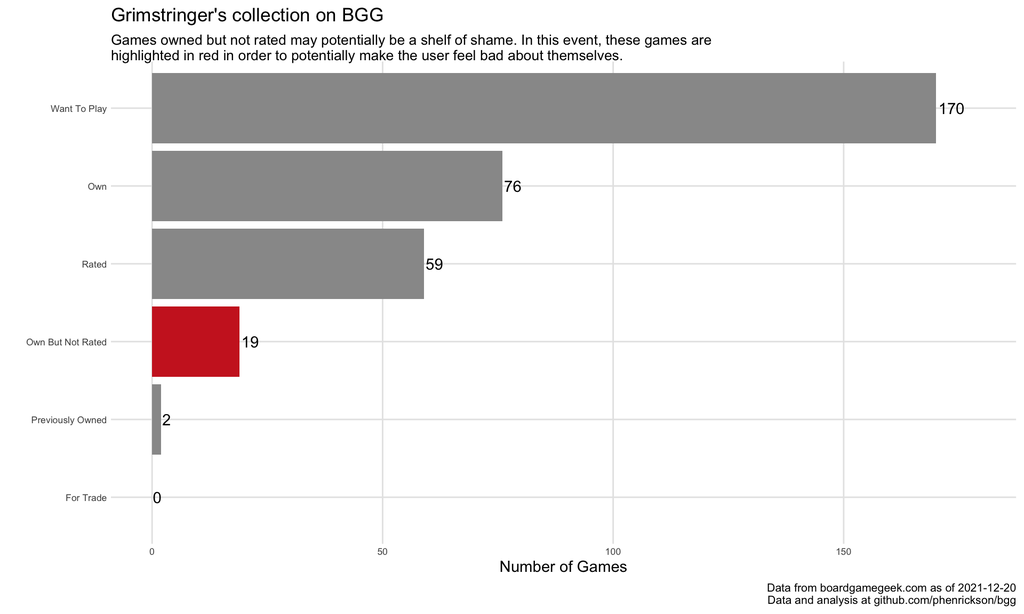

What years has the user owned/rated games from? While we can’t see when a user added or removed a game from their collection, we can look at their collection by the years in which their games were published.

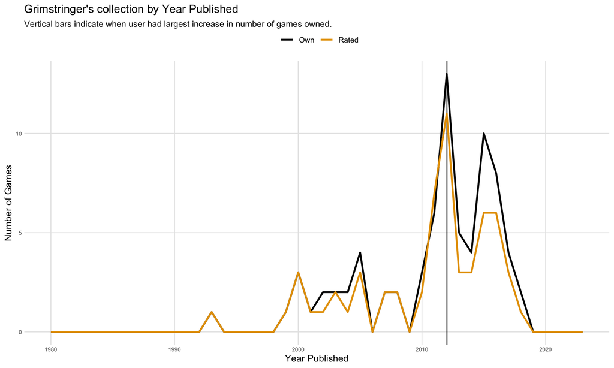

## 1.1 What types of games does Grimstringer own?

We can look at the most frequent types of categories, mechanics, designers, and artists that appear in a user’s collection.

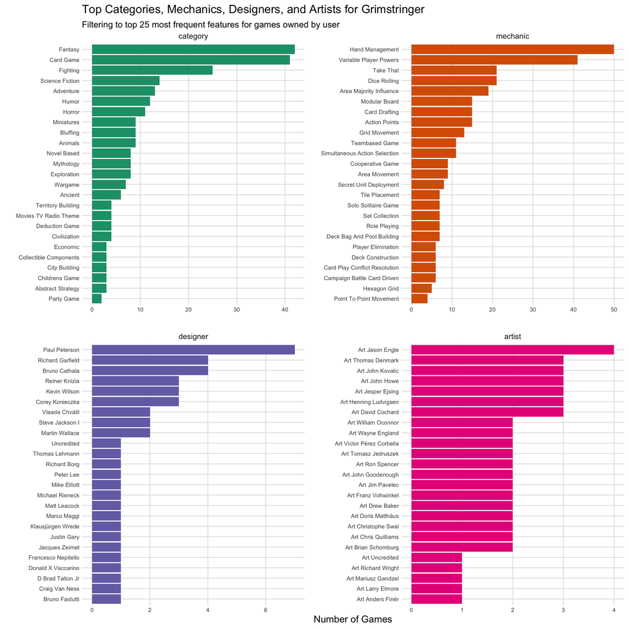

# 2 Modeling **Grimstringer’s** Collection

| username | dataset | period | games_owned | games_rated | games_played |
| --- | --- | --- | --- | --- | --- |
| Grimstringer | training | published before 2018 | 71 | 55 | 74 |
| Grimstringer | test | published 2018 or later | 2 | 1 | 2 |

There are two main (binary) outcomes we will be modeling for the user.

The first, **own** refers to whether the user currently lists a game as owned in their collection. The second, **played** refers to whether the user currently owns, has rated, or previously owned a game. This means the latter will generally have a larger list of games, but may still be a useful category to examine for people who play lots of games without necessarily owning them.

We will train predictive models to learn the probability that the user will own or play individual games based on their features.

## 2.1 Coefficients for Grimstringer

We can examine coefficients from the trained modes, which are penalized logistic regressions fit to our two main outcomes. Positive values indicate that a feature increases a user’s probabilility of owning/rating a game, while negative values indicate a feature decreases the probability.

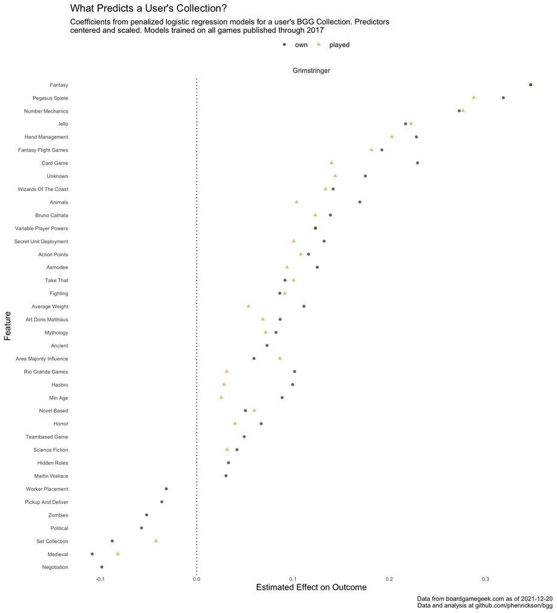

## 2.2 Visualizing Predictors for Grimstringer’s Collection

Why did the model identify these features? We can make density plots of the important features for predicting whether the user owned a game. Blue indicates the density for games owned by the user, while grey indicates the density for games not owned by the user.

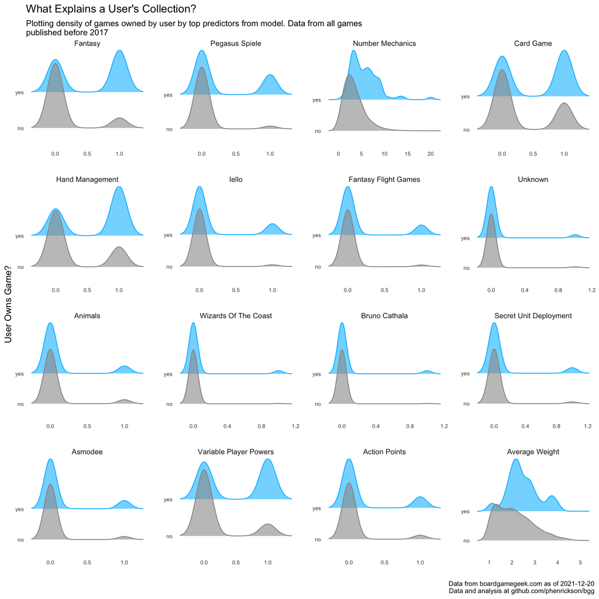

Binary predictors can be difficult to see with this visualization, so we can also directly examine the percentage of games in a user’s collection with a predictor vs the percentage of all games with that predictor.

| username | Feature | % of Games with Feature In_Collection | % of Games with Feature All_Games | Ratio |
| --- | --- | --- | --- | --- |
| Grimstringer | Wizards Of The Coast | 5.6% | 0.7% | 8.3 |
| Grimstringer | Pegasus Spiele | 31.0% | 4.3% | 7.3 |
| Grimstringer | Iello | 18.3% | 2.9% | 6.4 |
| Grimstringer | Fantasy Flight Games | 16.9% | 2.8% | 6.1 |
| Grimstringer | Mythology | 11.3% | 2.0% | 5.7 |
| Grimstringer | Take That | 25.4% | 5.8% | 4.4 |
| Grimstringer | Fantasy | 56.3% | 13.4% | 4.2 |
| Grimstringer | Horror | 14.1% | 3.6% | 3.9 |
| Grimstringer | Fighting | 32.4% | 8.7% | 3.7 |
| Grimstringer | Variable Player Powers | 52.1% | 15.4% | 3.4 |
| Grimstringer | Unknown | 5.6% | 1.7% | 3.3 |
| Grimstringer | Secret Unit Deployment | 9.9% | 3.1% | 3.1 |
| Grimstringer | Action Points | 18.3% | 6.5% | 2.8 |
| Grimstringer | Asmodee | 14.1% | 5.2% | 2.7 |
| Grimstringer | Hand Management | 64.8% | 26.2% | 2.5 |
| Grimstringer | Area Majority Influence | 26.8% | 10.7% | 2.5 |
| Grimstringer | Animals | 12.7% | 6.8% | 1.9 |
| Grimstringer | Ancient | 8.5% | 4.6% | 1.8 |
| Grimstringer | Card Game | 53.5% | 30.8% | 1.7 |
| Grimstringer | Hasbro | 7.0% | 4.5% | 1.6 |
| Grimstringer | Rio Grande Games | 7.0% | 5.1% | 1.4 |
| Grimstringer | Set Collection | 9.9% | 17.2% | 0.6 |
| Grimstringer | Medieval | 1.4% | 6.3% | 0.2 |
| Grimstringer | Negotiation | 0.0% | 4.0% | 0.0 |
| Grimstringer | Political | 0.0% | 3.4% | 0.0 |

# 3 Assess Model’s Performance on Training Set

Before predicting games in upcoming years, we can examine how well the model did and what games it liked in the training set. In this case, we used resampling techniques (cross validation) to ensure that the model had not seen a game before making its predictions.

## 3.1 Separation Plot

An easy way to examine the performance of classification model is to view a separation plot. We plot the predicted probabilities from the model for every game (from resampling) from lowest to highest. We then overlay a blue line for any game that the user does own. A good classifier is one that is able to *separate* the blue (games owned by the user) from the white (games not owned by the user), with most of the blue occurring at the highest probabilities (right side of the chart).

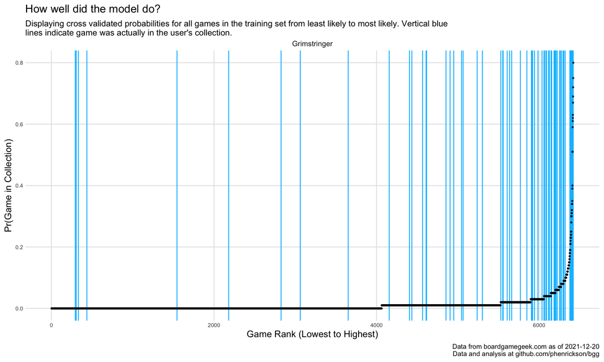

## 3.2 Top Games for **Grimstringer** from Training Set

We can display this information in table form, displaying the 100 games with the highest probability of ownership, adding a blue line when the user does own the game.

| username | yearpublished | game_id | name | pred_played | pred_own | actual_played | actual_own |
| --- | --- | --- | --- | --- | --- | --- | --- |
| Grimstringer | 2009 | 43111 | Chaos in the Old World | 0.61 | 0.80 | 0 | 0 |
| Grimstringer | 2015 | 177639 | Raptor | 0.45 | 0.75 | 1 | 1 |
| Grimstringer | 1997 | 42 | Tigris & Euphrates | 0.31 | 0.72 | 0 | 0 |
| Grimstringer | 2013 | 143185 | Smash Up: The Obligatory Cthulhu Set | 0.49 | 0.69 | 1 | 1 |
| Grimstringer | 2014 | 160018 | Smash Up: Monster Smash | 0.51 | 0.67 | 0 | 0 |
| Grimstringer | 2011 | 88408 | Nightfall | 0.63 | 0.63 | 0 | 0 |
| Grimstringer | 2013 | 134726 | Smash Up: Awesome Level 9000 | 0.51 | 0.62 | 0 | 0 |
| Grimstringer | 2017 | 216658 | Smash Up: What Were We Thinking? | 0.59 | 0.61 | 0 | 0 |
| Grimstringer | 2000 | 823 | The Lord of the Rings | 0.57 | 0.59 | 0 | 0 |
| Grimstringer | 2014 | 151004 | Smash Up: Science Fiction Double Feature | 0.62 | 0.51 | 1 | 1 |
| Grimstringer | 2009 | 45134 | Arcana | 0.43 | 0.51 | 0 | 0 |
| Grimstringer | 2016 | 177802 | Smash Up: It's Your Fault! | 0.49 | 0.40 | 0 | 0 |
| Grimstringer | 2016 | 205059 | Mansions of Madness: Second Edition | 0.31 | 0.39 | 0 | 0 |
| Grimstringer | 2017 | 216199 | Smash Up: Big in Japan | 0.34 | 0.35 | 1 | 1 |
| Grimstringer | 2015 | 168917 | Smash Up: Pretty Pretty Smash Up | 0.42 | 0.34 | 1 | 1 |
| Grimstringer | 1986 | 58 | Kings & Things | 0.11 | 0.34 | 0 | 0 |
| Grimstringer | 2005 | 15987 | Arkham Horror | 0.21 | 0.34 | 0 | 0 |
| Grimstringer | 2011 | 96848 | Mage Knight Board Game | 0.25 | 0.32 | 0 | 0 |
| Grimstringer | 2015 | 162559 | Smash Up: Munchkin | 0.33 | 0.32 | 1 | 1 |
| Grimstringer | 2012 | 115746 | War of the Ring: Second Edition | 0.09 | 0.31 | 0 | 0 |
| Grimstringer | 2012 | 122522 | Smash Up | 0.39 | 0.31 | 1 | 1 |
| Grimstringer | 2017 | 162886 | Spirit Island | 0.27 | 0.30 | 1 | 1 |
| Grimstringer | 2013 | 144325 | Munchkin Legends | 0.19 | 0.30 | 0 | 0 |
| Grimstringer | 2016 | 160010 | Conan | 0.09 | 0.30 | 0 | 0 |
| Grimstringer | 2012 | 104162 | Descent: Journeys in the Dark (Second Edition) | 0.27 | 0.30 | 1 | 1 |
| Grimstringer | 2016 | 198487 | Smash Up: Cease and Desist | 0.15 | 0.28 | 1 | 1 |
| Grimstringer | 2011 | 100423 | Elder Sign | 0.19 | 0.25 | 0 | 0 |
| Grimstringer | 2012 | 135116 | Rent a Hero | 0.24 | 0.25 | 0 | 0 |
| Grimstringer | 2015 | 170216 | Blood Rage | 0.22 | 0.24 | 0 | 0 |
| Grimstringer | 2016 | 200147 | Kanagawa | 0.15 | 0.24 | 0 | 0 |

[output cut: 70 more lines]

We can also more formally assess how well the model did in resampling by looking at the area under the receiver operating characteristic. A perfect model would receive a score of 1, while a model that cannot predict the outcome will default to a score of 0.5. The extent to which something is a *good* score depends on the setting, but generally anything in the .8 to .9 range is very good while the .7 to .8 range is perfectly acceptable.

| username | outcome_type | .metric | .estimator | .estimate |
| --- | --- | --- | --- | --- |
| Grimstringer | own | roc_auc | binary | 0.859 |
| Grimstringer | played | roc_auc | binary | 0.878 |

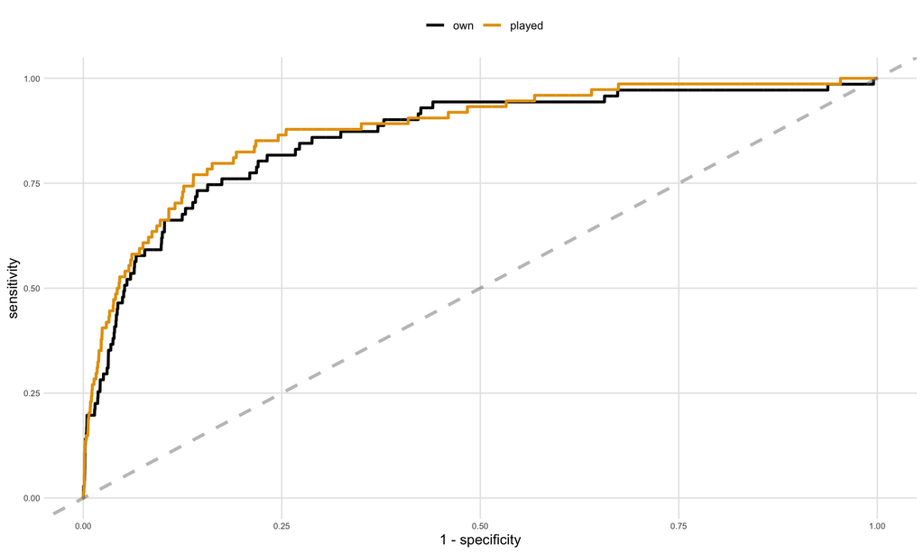

Another way to think about the model performance is to view its lift, or its ability to detect the positive outcomes over that of a null model. High lift indicates the model can much more quickly find all of the positive outcomes (in this case, games owned or played by the user), while a model with no lift is no better than random guessing.

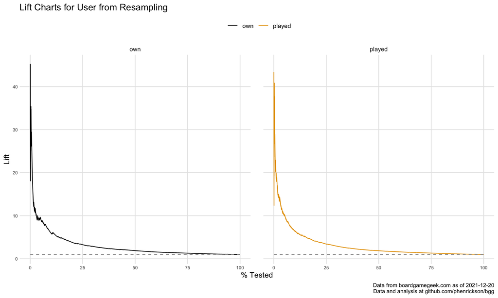

## 3.3 Most and Least Likely Games

What games does the model think Grimstringer is **most likely to own** that are **not** in their collection?

| username | yearpublished | game_id | name | pred_own | actual_own |
| --- | --- | --- | --- | --- | --- |
| Grimstringer | 2009 | 43111 | Chaos in the Old World | 0.80 | 0 |
| Grimstringer | 1997 | 42 | Tigris & Euphrates | 0.72 | 0 |
| Grimstringer | 2014 | 160018 | Smash Up: Monster Smash | 0.67 | 0 |
| Grimstringer | 2011 | 88408 | Nightfall | 0.63 | 0 |
| Grimstringer | 2013 | 134726 | Smash Up: Awesome Level 9000 | 0.62 | 0 |

What games does the model think Grimstringer is **least likely to own** that **are** in their collection?

| username | yearpublished | game_id | name | pred_own | actual_own |
| --- | --- | --- | --- | --- | --- |
| Grimstringer | 2003 | 7804 | Dracula | 0 | 1 |
| Grimstringer | 2005 | 19999 | Aton | 0 | 1 |
| Grimstringer | 2015 | 173346 | 7 Wonders Duel | 0 | 1 |
| Grimstringer | 2000 | 2655 | Hive | 0 | 1 |
| Grimstringer | 2016 | 177524 | ICECOOL | 0 | 1 |

## 3.4 Top Games by Year

Top 25 games most likely to be owned by the user in each year, highlighting in blue the games that the user has owned/played.

| rank | 2009 | 2010 | 2011 | 2012 | 2013 | 2014 | 2015 | 2016 | 2017 |
| --- | --- | --- | --- | --- | --- | --- | --- | --- | --- |
| 1 | Chaos in the Old World | Dungeons & Dragons: Castle Ravenloft Board Game | Nightfall | War of the Ring: Second Edition | Smash Up: The Obligatory Cthulhu Set | Smash Up: Monster Smash | Raptor | Smash Up: It's Your Fault! | Smash Up: What Were We Thinking? |
| 2 | Arcana | Battles of Westeros | Mage Knight Board Game | Smash Up | Smash Up: Awesome Level 9000 | Smash Up: Science Fiction Double Feature | Smash Up: Pretty Pretty Smash Up | Mansions of Madness: Second Edition | Smash Up: Big in Japan |
| 3 | The Adventurers: The Temple of Chac | Runewars | Elder Sign | Descent: Journeys in the Dark (Second Edition) | Munchkin Legends | Ultimate Werewolf | Smash Up: Munchkin | Conan | Spirit Island |
| 4 | Thunderstone | Heroscape Master Set: Battle for the Underdark | Mansions of Madness | Rent a Hero | Tash-Kalar: Arena of Legends | The Lord of the Ice Garden | Blood Rage | Smash Up: Cease and Desist | Paper Tales |
| 5 | Dungeon Twister 2: Prison | Dragonheart | Blood Bowl: Team Manager – The Card Game | Dungeon Command: Curse of Undeath | Eldritch Horror | Evolution | Cthulhu Wars | Kanagawa | Gloomhaven |
| 6 | Stronghold | Dominant Species | Dungeon Fighter | Munchkin Conan | Munchkin Pathfinder | Imperial Settlers | Mission: Red Planet (Second Edition) | Magic: The Gathering – Arena of the Planeswalkers: Shadows over Innistrad | Hunt for the Ring |
| 7 | The Werewolves of Miller's Hollow: The Village | The Hobbit | Dungeons & Dragons: Wrath of Ashardalon Board Game | Game of Thrones: The Card Game | The Witches: A Discworld Game | Golem Arcana | Epic PVP: Fantasy | Aeon's End | Battle for Rokugan |
| 8 | Cyclades | Labyrinth: The War on Terror, 2001 – ? | Thunderstone: Dragonspire | Legends of Andor | 8 Masters' Revenge | Valley of the Kings | Runebound (Third Edition) | A Game of Thrones: Hand of the King | Betrayal at Baldur's Gate |
| 9 | Claustrophobia | Defenders of the Realm | Drako: Dragon & Dwarves | Wiz-War (Eighth Edition) | Dungeon Command: Blood of Gruumsh | The Witcher Adventure Game | Krosmaster: Quest | Histrio | Fog of Love |
| 10 | Age of Conan: The Strategy Board Game | Merchants & Marauders | A Game of Thrones: The Board Game (Second Edition) | Dungeon Command: Sting of Lolth | City of Iron | The Battle of Five Armies | Exploding Kittens: NSFW Deck | Exceed Fighting System | Lovecraft Letter |
| 11 | Axis & Allies Pacific 1940 | Earth Reborn | Last Will | Dungeon Command: Heart of Cormyr | Patchistory | Abyss | Warhammer Quest: The Adventure Card Game | The Others | Fallout |
| 12 | Dungeon Lords | Luna | Dungeons & Dragons: The Legend of Drizzt Board Game | Dungeon Command: Tyranny of Goblins | Dungeon Twister: The Card Game | Star Wars: Imperial Assault | 504 | Thunder & Lightning | Jump Drive |
| 13 | Middle-Earth Quest | Magestorm | Discworld: Ankh-Morpork | Puzzle Strike (Third Edition) | Theseus: The Dark Orbit | oddball Äeronauts | Heroes | The Oracle of Delphi | Queendomino |
| 14 | Summoner Wars | Cadwallon: City of Thieves | Nightfall: Martial Law | Clash of Cultures | Thunderstone Advance: Numenera | Shinobi WAT-AAH! | The Big Book of Madness | Zany Penguins | Apocrypha Adventure Card Game: Box One – The World |
| 15 | Krysis | Space Hulk: Death Angel – The Card Game | Belfort | The Hobbit Card Game | Dungeon Roll | Three Kingdoms Redux | Magic: The Gathering – Arena of the Planeswalkers | Hero Realms | Sword & Sorcery |
| 16 | Summoner Wars: Phoenix Elves vs Tundra Orcs | 20th Century | Takenoko | Tzolk'in: The Mayan Calendar | A Study in Emerald | Munchkin Panic | Mombasa | Junta: Las Cartas | Arkham Noir: Case #1 – The Witch Cult Murders |
| 17 | Bridge Troll | Horus Heresy | Mundus Novus | Robinson Crusoe: Adventures on the Cursed Island | Tales & Games: The Three Little Pigs | Onirim (Second Edition) | Dungeons & Dragons: Temple of Elemental Evil Board Game | Inis | The Expanse Board Game |
| 18 | Castle Panic | Onirim | Munchkin Axe Cop | Coup | Forbidden Desert | Five Tribes | Star Realms: Colony Wars | The Arrival | Magic Maze |
| 19 | Tomb: Cryptmaster | Flash Duel | Dungeon Petz | Neuroshima: Convoy | Thunderstone: Starter Set | Doomtown: Reloaded | Epic Card Game | Aventuria: Adventure Card Game | The Dresden Files Cooperative Card Game |
| 20 | Mr. Jack in New York | DungeonQuest (Third Edition) | Dungeons & Dragons: Conquest of Nerath Board Game | Love Letter | Eight-Minute Empire: Legends | Hyperborea | Love Letter: The Hobbit – The Battle of the Five Armies | Cry Havoc | Civilization: A New Dawn |
| 21 | The Three Musketeers: The Queen's Pendants | 51st State | Eminent Domain | Thunderstone Advance: Towers of Ruin | LEADERS: The Combined Strategy Game | Munchkin Adventure Time | Dale of Merchants | Crazy Karts | Alien Artifacts |
| 22 | Penny Arcade: The Card Game | Innovation | Panic Station | Kemet | BattleCON: Devastation of Indines | Heroes of Normandie | Through the Ages: A New Story of Civilization | Perdition's Mouth: Abyssal Rift | Runewars Miniatures Game |
| 23 | Jaipur | Puzzle Strike | Pergamemnon | Mage Wars Arena | Warhammer: Diskwars | Haru Ichiban | Munchkin Oz | Vast: The Crystal Caverns | Aristeia! |
| 24 | Nemo's War | Escape from the Aliens in Outer Space | Tales & Games: The Hare & the Tortoise | Pixel Tactics | Legacy: The Testament of Duke de Crecy | Alchemists | Sylvion | Codex: Card-Time Strategy – Deluxe Set | Guards of Atlantis: Tabletop MOBA |
| 25 | Atlantis | Three-Dragon Ante: Emperor's Gambit | Revolver | Seasons | Boss Monster: The Dungeon Building Card Game | Krosmaster Junior | Kenjin | Great Western Trail | Mythic Battles: Pantheon |

## 3.5 Interactive Predictions from Resampling

Interactive table for predictions from resampling.

|  | username | yearpublished | rank | game_id | name | pred_played | pred_own | actual_played | actual_own |
| --- | --- | --- | --- | --- | --- | --- | --- | --- | --- |
| 1 | Grimstringer | 1900 | 259 | 15878 | Rummy | 0.03 | 0.05 | 0 | 0 |
| 2 | Grimstringer | 1900 | 316 | 2093 | Mahjong | 0.05 | 0.04 | 0 | 0 |
| 3 | Grimstringer | 1900 | 343 | 11670 | The Game of Authors | 0.02 | 0.04 | 0 | 0 |
| 4 | Grimstringer | 1900 | 385 | 10213 | Fox and Geese | 0.02 | 0.03 | 0 | 0 |
| 5 | Grimstringer | 1900 | 527 | 171 | Chess | 0.01 | 0.02 | 1 | 1 |
| 6 | Grimstringer | 1900 | 784 | 2136 | Pachisi | 0.02 | 0.02 | 0 | 0 |
| 7 | Grimstringer | 1900 | 785 | 2386 | Chinese Checkers | 0.01 | 0.02 | 0 | 0 |
| 8 | Grimstringer | 1900 | 804 | 2785 | Game of Goose | 0.01 | 0.02 | 0 | 0 |
| 9 | Grimstringer | 1900 | 812 | 10799 | Old Maid | 0.01 | 0.02 | 0 | 0 |
| 10 | Grimstringer | 1900 | 896 | 11901 | Tic-Tac-Toe | 0.01 | 0.01 | 0 | 0 |

[output cut: 6410 more lines]

# 4 Validating the Model on 2018

How well did a model trained on a user’s collection through 2017 perform in predicting games for the user from 2018?

| username | outcome_type | yearpublished | .metric | .estimator | .estimate |
| --- | --- | --- | --- | --- | --- |
| Grimstringer | own | 2018 | roc_auc | binary | 0.876 |
| Grimstringer | played | 2018 | roc_auc | binary | 0.854 |

Table of top 25 games from 2018, highlighting games that the user owns.

| username | yearpublished | game_id | name | pred_own | pred_played | actual_own | actual_played |
| --- | --- | --- | --- | --- | --- | --- | --- |
| Grimstringer | 2018 | 238393 | Monolith Arena | 0.32 | 0.31 | 0 | 0 |
| Grimstringer | 2018 | 241225 | Smash Up: That '70s Expansion | 0.22 | 0.21 | 0 | 0 |
| Grimstringer | 2018 | 247724 | Smash Up: Oops, You Did It Again | 0.21 | 0.20 | 0 | 0 |
| Grimstringer | 2018 | 199792 | Everdell | 0.17 | 0.12 | 0 | 0 |
| Grimstringer | 2018 | 246855 | Boss Monster: Rise of the Minibosses | 0.15 | 0.14 | 0 | 0 |
| Grimstringer | 2018 | 257501 | KeyForge: Call of the Archons | 0.14 | 0.11 | 0 | 0 |
| Grimstringer | 2018 | 254591 | Heroes of Terrinoth | 0.12 | 0.11 | 0 | 0 |
| Grimstringer | 2018 | 205896 | Rising Sun | 0.11 | 0.20 | 0 | 0 |
| Grimstringer | 2018 | 242639 | Treasure Island | 0.11 | 0.10 | 0 | 0 |
| Grimstringer | 2018 | 260300 | Dungeon Mayhem | 0.10 | 0.11 | 0 | 0 |
| Grimstringer | 2018 | 244115 | Shards of Infinity | 0.09 | 0.09 | 0 | 0 |
| Grimstringer | 2018 | 209324 | The World of SMOG: Rise of Moloch | 0.08 | 0.05 | 0 | 0 |
| Grimstringer | 2018 | 218421 | Street Masters | 0.07 | 0.06 | 0 | 0 |
| Grimstringer | 2018 | 237182 | Root | 0.07 | 0.07 | 0 | 0 |
| Grimstringer | 2018 | 244654 | Wildlands | 0.07 | 0.05 | 0 | 0 |
| Grimstringer | 2018 | 247763 | Underwater Cities | 0.07 | 0.04 | 0 | 0 |
| Grimstringer | 2018 | 256569 | Castle Rampage | 0.07 | 0.07 | 0 | 0 |
| Grimstringer | 2018 | 261594 | Warhammer Underworlds: Nightvault | 0.07 | 0.07 | 0 | 0 |
| Grimstringer | 2018 | 207729 | The Edge: Dawnfall | 0.06 | 0.06 | 0 | 0 |
| Grimstringer | 2018 | 218479 | Cerebria: The Inside World | 0.06 | 0.06 | 0 | 0 |
| Grimstringer | 2018 | 257499 | Arkham Horror (Third Edition) | 0.06 | 0.06 | 0 | 0 |
| Grimstringer | 2018 | 198830 | Heroes of Land, Air & Sea | 0.05 | 0.06 | 0 | 0 |
| Grimstringer | 2018 | 205127 | Haven | 0.05 | 0.04 | 0 | 0 |
| Grimstringer | 2018 | 222509 | Lords of Hellas | 0.05 | 0.04 | 0 | 0 |
| Grimstringer | 2018 | 239840 | Micropolis | 0.05 | 0.05 | 0 | 0 |

# 5 Predicting Upcoming Games (2018 and On) for **Grimstringer**

Examine the top games for the test set.

| username | yearpublished | game_id | name | rank | own | played |
| --- | --- | --- | --- | --- | --- | --- |
| Grimstringer | 2018 | 238393 | Monolith Arena | 1 | 0.32 | 0.31 |
| Grimstringer | 2018 | 241225 | Smash Up: That '70s Expansion | 2 | 0.22 | 0.21 |
| Grimstringer | 2018 | 247724 | Smash Up: Oops, You Did It Again | 3 | 0.21 | 0.20 |
| Grimstringer | 2018 | 199792 | Everdell | 4 | 0.17 | 0.12 |
| Grimstringer | 2018 | 246855 | Boss Monster: Rise of the Minibosses | 5 | 0.15 | 0.14 |
| Grimstringer | 2018 | 257501 | KeyForge: Call of the Archons | 6 | 0.14 | 0.11 |
| Grimstringer | 2018 | 254591 | Heroes of Terrinoth | 7 | 0.12 | 0.11 |
| Grimstringer | 2018 | 205896 | Rising Sun | 8 | 0.11 | 0.20 |
| Grimstringer | 2018 | 242639 | Treasure Island | 9 | 0.11 | 0.10 |
| Grimstringer | 2018 | 260300 | Dungeon Mayhem | 10 | 0.10 | 0.11 |
| Grimstringer | 2018 | 244115 | Shards of Infinity | 11 | 0.09 | 0.09 |
| Grimstringer | 2018 | 209324 | The World of SMOG: Rise of Moloch | 12 | 0.08 | 0.05 |
| Grimstringer | 2018 | 256569 | Castle Rampage | 13 | 0.07 | 0.07 |
| Grimstringer | 2018 | 247763 | Underwater Cities | 14 | 0.07 | 0.04 |
| Grimstringer | 2018 | 218421 | Street Masters | 15 | 0.07 | 0.06 |
| Grimstringer | 2018 | 261594 | Warhammer Underworlds: Nightvault | 16 | 0.07 | 0.07 |
| Grimstringer | 2018 | 244654 | Wildlands | 17 | 0.07 | 0.05 |
| Grimstringer | 2018 | 237182 | Root | 18 | 0.07 | 0.07 |
| Grimstringer | 2018 | 207729 | The Edge: Dawnfall | 19 | 0.06 | 0.06 |
| Grimstringer | 2018 | 257499 | Arkham Horror (Third Edition) | 20 | 0.06 | 0.06 |
| Grimstringer | 2018 | 218479 | Cerebria: The Inside World | 21 | 0.06 | 0.06 |
| Grimstringer | 2018 | 222509 | Lords of Hellas | 22 | 0.05 | 0.04 |
| Grimstringer | 2018 | 205127 | Haven | 23 | 0.05 | 0.04 |
| Grimstringer | 2018 | 198830 | Heroes of Land, Air & Sea | 24 | 0.05 | 0.06 |
| Grimstringer | 2018 | 239840 | Micropolis | 25 | 0.05 | 0.05 |
| Grimstringer | 2019 | 274637 | Unmatched: Battle of Legends, Volume One | 1 | 0.55 | 0.54 |
| Grimstringer | 2019 | 274638 | Unmatched: Robin Hood vs. Bigfoot | 2 | 0.48 | 0.50 |
| Grimstringer | 2019 | 264220 | Tainted Grail: The Fall of Avalon | 3 | 0.23 | 0.23 |
| Grimstringer | 2019 | 270844 | Imperial Settlers: Empires of the North | 4 | 0.19 | 0.17 |
| Grimstringer | 2019 | 269385 | The Lord of the Rings: Journeys in Middle-Earth | 5 | 0.15 | 0.15 |
| Grimstringer | 2019 | 272453 | KeyForge: Age of Ascension | 6 | 0.14 | 0.11 |
| Grimstringer | 2019 | 295564 | Unmatched Game System | 7 | 0.13 | 0.12 |
| Grimstringer | 2019 | 274364 | Watergate | 8 | 0.12 | 0.15 |
| Grimstringer | 2019 | 181819 | Sorcerer | 9 | 0.09 | 0.06 |
| Grimstringer | 2019 | 169427 | Middara: Unintentional Malum – Act 1 | 10 | 0.09 | 0.09 |
| Grimstringer | 2019 | 267652 | Dungeonology: The Expedition | 11 | 0.09 | 0.09 |
| Grimstringer | 2019 | 285775 | KeyForge: Worlds Collide | 12 | 0.08 | 0.08 |
| Grimstringer | 2019 | 251551 | Dale of Merchants Collection | 13 | 0.07 | 0.06 |
| Grimstringer | 2019 | 299121 | Machina Arcana (Second/Third Edition) | 14 | 0.07 | 0.06 |
| Grimstringer | 2019 | 239942 | Black Rose Wars | 15 | 0.06 | 0.05 |
| Grimstringer | 2019 | 274590 | Smash Up: World Tour – Culture Shock | 16 | 0.06 | 0.05 |
| Grimstringer | 2019 | 271088 | Ishtar: Gardens of Babylon | 17 | 0.06 | 0.05 |
| Grimstringer | 2019 | 155065 | Lifeform | 18 | 0.06 | 0.04 |
| Grimstringer | 2019 | 265736 | Tiny Towns | 19 | 0.06 | 0.05 |
| Grimstringer | 2019 | 285774 | Marvel Champions: The Card Game | 20 | 0.06 | 0.05 |
| Grimstringer | 2019 | 253344 | Cthulhu: Death May Die | 21 | 0.05 | 0.04 |
| Grimstringer | 2019 | 271060 | Pathfinder Adventure Card Game: Core Set | 22 | 0.05 | 0.05 |
| Grimstringer | 2019 | 241451 | Aeon's End: Legacy | 23 | 0.05 | 0.04 |
| Grimstringer | 2019 | 284760 | Disney Villainous: Evil Comes Prepared | 24 | 0.05 | 0.05 |
| Grimstringer | 2019 | 287754 | Warhammer Underworlds: Beastgrave | 25 | 0.05 | 0.06 |
| Grimstringer | 2020 | 294484 | Unmatched: Cobble & Fog | 1 | 0.50 | 0.47 |
| Grimstringer | 2020 | 325635 | Unmatched: Little Red Riding Hood vs. Beowulf | 2 | 0.48 | 0.50 |
| Grimstringer | 2020 | 284777 | Unmatched: Jurassic Park – InGen vs Raptors | 3 | 0.19 | 0.15 |
| Grimstringer | 2020 | 299252 | Here to Slay | 4 | 0.18 | 0.17 |
| Grimstringer | 2020 | 291457 | Gloomhaven: Jaws of the Lion | 5 | 0.18 | 0.16 |
| Grimstringer | 2020 | 295577 | Dungeon Mayhem: Monster Madness | 6 | 0.17 | 0.19 |
| Grimstringer | 2020 | 299047 | Disney Villainous: Perfectly Wretched | 7 | 0.16 | 0.16 |
| Grimstringer | 2020 | 315060 | Unmatched: Buffy the Vampire Slayer | 8 | 0.15 | 0.12 |
| Grimstringer | 2020 | 303552 | Magic: The Gathering – Unsanctioned | 9 | 0.15 | 0.14 |
| Grimstringer | 2020 | 276654 | 7 Souls | 10 | 0.12 | 0.09 |
| Grimstringer | 2020 | 276801 | Valhallamas | 11 | 0.12 | 0.11 |
| Grimstringer | 2020 | 245659 | Vampire: The Masquerade – Vendetta | 12 | 0.10 | 0.09 |
| Grimstringer | 2020 | 256317 | Guild Master | 13 | 0.10 | 0.15 |
| Grimstringer | 2020 | 301607 | KeyForge: Mass Mutation | 14 | 0.09 | 0.08 |
| Grimstringer | 2020 | 302465 | Obsidia | 15 | 0.09 | 0.12 |
| Grimstringer | 2020 | 312346 | Munchkin Disney | 16 | 0.09 | 0.09 |
| Grimstringer | 2020 | 246900 | Eclipse: Second Dawn for the Galaxy | 17 | 0.08 | 0.08 |
| Grimstringer | 2020 | 259061 | Skytear | 18 | 0.08 | 0.07 |
| Grimstringer | 2020 | 300010 | Dragomino | 19 | 0.06 | 0.07 |
| Grimstringer | 2020 | 298572 | Cosmic Encounter Duel | 20 | 0.06 | 0.05 |
| Grimstringer | 2020 | 262274 | D6: Dungeons, Dudes, Dames, Danger, Dice and Dragons! | 21 | 0.06 | 0.07 |
| Grimstringer | 2020 | 274072 | Omen: Heir to the Dunes | 22 | 0.05 | 0.03 |
| Grimstringer | 2020 | 279497 | The Ratcatcher: The Solo Adventure Game | 23 | 0.05 | 0.04 |
| Grimstringer | 2020 | 293014 | Nidavellir | 24 | 0.05 | 0.05 |
| Grimstringer | 2020 | 282544 | Video Vortex | 25 | 0.05 | 0.04 |

## 5.1 Interactive Table for Upcoming Games 2018 and On

|  | username | yearpublished | game_id | name | rank | own | played |
| --- | --- | --- | --- | --- | --- | --- | --- |
| 1 | Grimstringer | 2019 | 274637 | Unmatched: Battle of Legends, Volume One | 1 | 0.55 | 0.54 |
| 2 | Grimstringer | 2020 | 294484 | Unmatched: Cobble &amp; Fog | 2 | 0.5 | 0.47 |
| 3 | Grimstringer | 2019 | 274638 | Unmatched: Robin Hood vs. Bigfoot | 3 | 0.48 | 0.5 |
| 4 | Grimstringer | 2020 | 325635 | Unmatched: Little Red Riding Hood vs. Beowulf | 4 | 0.48 | 0.5 |
| 5 | Grimstringer | 2018 | 238393 | Monolith Arena | 5 | 0.32 | 0.31 |
| 6 | Grimstringer | 2019 | 264220 | Tainted Grail: The Fall of Avalon | 6 | 0.23 | 0.23 |
| 7 | Grimstringer | 2018 | 241225 | Smash Up: That '70s Expansion | 7 | 0.22 | 0.21 |
| 8 | Grimstringer | 2018 | 247724 | Smash Up: Oops, You Did It Again | 8 | 0.21 | 0.2 |
| 9 | Grimstringer | 2019 | 270844 | Imperial Settlers: Empires of the North | 9 | 0.19 | 0.17 |
| 10 | Grimstringer | 2020 | 284777 | Unmatched: Jurassic Park – InGen vs Raptors | 10 | 0.19 | 0.15 |

[output cut: 1923 more lines]